# Untitled (2)

```python
import pandas as pd
import numpy as np
import sklearn
from sklearn.model_selection import train_test_split,cross_validate,cross_val_score,RepeatedStratifiedKFold,GridSearchCV,cross_val_predict
from sklearn.linear_model import LogisticRegression
from sklearn.preprocessing import RobustScaler
import statsmodels.api as sm
from sklearn.metrics import r2_score
import matplotlib.pyplot as plt
import seaborn as sns
import warnings
warnings.filterwarnings('ignore')
```

```python
df = pd.read_csv('SA heart.csv')
```

```python
df.head()
```

|  | row.names | sbp | tobacco | ldl | adiposity | famhist | typea | obesity | alcohol | age | chd |
| --- | --- | --- | --- | --- | --- | --- | --- | --- | --- | --- | --- |
| 0 | 1 | 160 | 12.00 | 5.73 | 23.11 | Present | 49 | 25.30 | 97.20 | 52 | 1 |
| 1 | 2 | 144 | 0.01 | 4.41 | 28.61 | Absent | 55 | 28.87 | 2.06 | 63 | 1 |
| 2 | 3 | 118 | 0.08 | 3.48 | 32.28 | Present | 52 | 29.14 | 3.81 | 46 | 0 |
| 3 | 4 | 170 | 7.50 | 6.41 | 38.03 | Present | 51 | 31.99 | 24.26 | 58 | 1 |
| 4 | 5 | 134 | 13.60 | 3.50 | 27.78 | Present | 60 | 25.99 | 57.34 | 49 | 1 |

# Question 2

## (a) Build a logistic regression model to predict the probability of getting CHD

```python
X = df.drop(['row.names','chd'],axis = 1)
y = df.chd
```

```python
df['chd'].value_counts()
```

```
0    302
1    160
Name: chd, dtype: int64
```

```python
X_trn,X_val,y_trn,y_val = train_test_split(X,y,test_size = .23,stratify = y)
```

```python
le = sklearn.preprocessing.LabelEncoder()
```

```python
X_val['famhist'].unique()
```

```
array(['Present', 'Absent'], dtype=object)
```

```python
X_trn.loc[:,'famhist'] = le.fit_transform(X_trn['famhist'])
```

```python
X_val.loc[:,'famhist'] = le.transform(X_val['famhist'])
```

```python
rs = RobustScaler()
```

```python
X_trn_rs = rs.fit_transform(X_trn)
X_val_rs = rs.transform(X_val)
```

```python
logreg = LogisticRegression()
logreg.fit(X_trn_rs,y_trn)
model = LogisticRegression()
```

```python
print("ACCURACY      :",np.round(cross_validate(model,X_trn_rs,y_trn,cv=7)['test_score'].mean()*100,2))
print("ROC AUC SCORE :",np.round(cross_val_score(model, X_trn_rs, y_trn, scoring="roc_auc", cv = 7).mean()*100,2))
```

```
ACCURACY      : 76.32
ROC AUC SCORE : 79.45
```

## i. Find out which features are statistically significant in the logistic regression model built in (a).

```python
import statsmodels.api as sm
from sklearn.metrics import classification_report, confusion_matrix
from sklearn.model_selection import train_test_split
from sklearn.preprocessing import StandardScaler
from sklearn.linear_model import LogisticRegression
```

```python
# Adding the column of ones so it can provide intercept.
XX_trn = sm.add_constant(X_trn)
XXX_trn = sm.add_constant(X_trn)
model=sm.Logit(y_trn,XX_trn,random_state=0)
result0=model.fit()
print(result0.summary())
```

```
Optimization terminated successfully.
         Current function value: 0.486709
         Iterations 7
                           Logit Regression Results
==============================================================================
Dep. Variable:                    chd   No. Observations:                  355
Model:                          Logit   Df Residuals:                      345
Method:                           MLE   Df Model:                            9
Date:                Thu, 03 Dec 2020   Pseudo R-squ.:                  0.2457
Time:                        10:06:22   Log-Likelihood:                -172.78
converged:                       True   LL-Null:                       -229.06
Covariance Type:            nonrobust   LLR p-value:                 4.432e-20
==============================================================================
                 coef    std err          z      P>|z|      [0.025      0.975]
------------------------------------------------------------------------------
const         -7.2056      1.564     -4.608      0.000     -10.270      -4.141
sbp            0.0061      0.007      0.912      0.362      -0.007       0.019
tobacco        0.0919      0.030      3.052      0.002       0.033       0.151
ldl            0.2358      0.077      3.064      0.002       0.085       0.387
adiposity      0.0207      0.035      0.597      0.551      -0.047       0.089
famhist        0.9056      0.267      3.390      0.001       0.382       1.429
typea          0.0479      0.015      3.229      0.001       0.019       0.077
obesity       -0.0643      0.051     -1.254      0.210      -0.165       0.036
alcohol       -0.0007      0.005     -0.140      0.889      -0.011       0.010
age            0.0517      0.015      3.435      0.001       0.022       0.081
==============================================================================
```

## ii. Build a new logistic regression model using only significant features.

Below Code automatically detects p values greater than 0.05 and removes them and does this step by step

```python
for _ in range(11):
  model=sm.Logit(y_trn,XX_trn,random_state=0)
  result=model.fit()
  print(result.summary())
  p = pd.DataFrame(result.pvalues)
  p.columns = ['p_vals']
  shit = np.argmax(p['p_vals'])
  #print(shit,max((p['p_vals'])))
  #XX_trn = XX_trn.drop([shit],axis = 1)
  XX_trn = XX_trn.drop(XX_trn.columns[shit], axis=1)
  if max(p.values) < .051:
    break
```

```
Optimization terminated successfully.
         Current function value: 0.486709
         Iterations 7
                           Logit Regression Results
==============================================================================
Dep. Variable:                    chd   No. Observations:                  355
Model:                          Logit   Df Residuals:                      345
Method:                           MLE   Df Model:                            9
Date:                Thu, 03 Dec 2020   Pseudo R-squ.:                  0.2457
Time:                        10:06:22   Log-Likelihood:                -172.78
converged:                       True   LL-Null:                       -229.06
Covariance Type:            nonrobust   LLR p-value:                 4.432e-20
==============================================================================
                 coef    std err          z      P>|z|      [0.025      0.975]
------------------------------------------------------------------------------
const         -7.2056      1.564     -4.608      0.000     -10.270      -4.141
sbp            0.0061      0.007      0.912      0.362      -0.007       0.019
tobacco        0.0919      0.030      3.052      0.002       0.033       0.151
ldl            0.2358      0.077      3.064      0.002       0.085       0.387
adiposity      0.0207      0.035      0.597      0.551      -0.047       0.089
famhist        0.9056      0.267      3.390      0.001       0.382       1.429
typea          0.0479      0.015      3.229      0.001       0.019       0.077
obesity       -0.0643      0.051     -1.254      0.210      -0.165       0.036
alcohol       -0.0007      0.005     -0.140      0.889      -0.011       0.010
age            0.0517      0.015      3.435      0.001       0.022       0.081
==============================================================================
Optimization terminated successfully.
         Current function value: 0.486737
         Iterations 7
                           Logit Regression Results
==============================================================================
Dep. Variable:                    chd   No. Observations:                  355
Model:                          Logit   Df Residuals:                      346
Method:                           MLE   Df Model:                            8
Date:                Thu, 03 Dec 2020   Pseudo R-squ.:                  0.2456
Time:                        10:06:22   Log-Likelihood:                -172.79
converged:                       True   LL-Null:                       -229.06
Covariance Type:            nonrobust   LLR p-value:                 1.145e-20
==============================================================================
                 coef    std err          z      P>|z|      [0.025      0.975]
```

[output cut: 65 more lines]

```
Method:                           MLE   Df Model:                            5
Date:                Thu, 03 Dec 2020   Pseudo R-squ.:                  0.2402
Time:                        10:06:23   Log-Likelihood:                -174.05
converged:                       True   LL-Null:                       -229.06
Covariance Type:            nonrobust   LLR p-value:                 4.040e-22
==============================================================================
                 coef    std err          z      P>|z|      [0.025      0.975]
------------------------------------------------------------------------------
const         -7.6438      1.171     -6.528      0.000      -9.939      -5.349
tobacco        0.0895      0.029      3.062      0.002       0.032       0.147
ldl            0.2300      0.072      3.206      0.001       0.089       0.371
famhist        0.8771      0.265      3.314      0.001       0.358       1.396
typea          0.0457      0.015      3.117      0.002       0.017       0.074
age            0.0581      0.013      4.602      0.000       0.033       0.083
==============================================================================
```

```python
p.index
```

```
Index(['const', 'tobacco', 'ldl', 'famhist', 'typea', 'age'], dtype='object')
```

```python
stat_signi = p.index
```

```python
model=sm.Logit(y_trn,XXX_trn[stat_signi],random_state=0)
result1=model.fit()
print(result1.summary())
print(result1.aic)
```

```
Optimization terminated successfully.
         Current function value: 0.490269
         Iterations 7
                           Logit Regression Results
==============================================================================
Dep. Variable:                    chd   No. Observations:                  355
Model:                          Logit   Df Residuals:                      349
Method:                           MLE   Df Model:                            5
Date:                Thu, 03 Dec 2020   Pseudo R-squ.:                  0.2402
Time:                        10:06:23   Log-Likelihood:                -174.05
converged:                       True   LL-Null:                       -229.06
Covariance Type:            nonrobust   LLR p-value:                 4.040e-22
==============================================================================
                 coef    std err          z      P>|z|      [0.025      0.975]
------------------------------------------------------------------------------
const         -7.6438      1.171     -6.528      0.000      -9.939      -5.349
tobacco        0.0895      0.029      3.062      0.002       0.032       0.147
ldl            0.2300      0.072      3.206      0.001       0.089       0.371
famhist        0.8771      0.265      3.314      0.001       0.358       1.396
typea          0.0457      0.015      3.117      0.002       0.017       0.074
age            0.0581      0.013      4.602      0.000       0.033       0.083
==============================================================================
360.09116693661
```

```python
print('Is the model with Significant estimators better?',result.aic < result0.aic) #this model is better as it has lower AIC than the model with all predictors
#print(result.aic,result0.aic)
```

```
Is the model with Significant estimators better? True
```

# iii. Write an estimated logistic regression model obtained in (ii)

**chd** = (**const** x -7.6438) + (**tobacco** x 0.0895) + (**ldl** x 0.2300) + (**famhist** x 0.8771) + (**typea** x 0.0457) + (**age** x 0.0581)

# Odd's Ratio Graphs

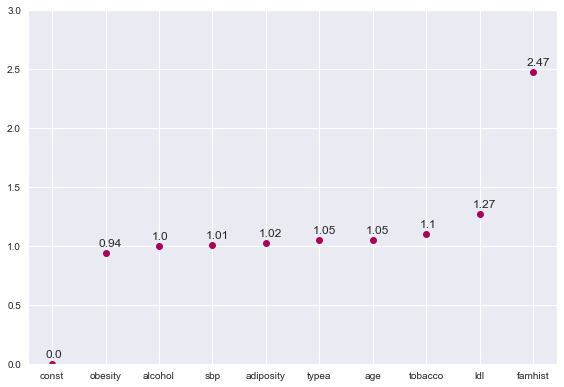

```python
fig = plt.figure()
ax = fig.add_subplot(111)
values = np.round(np.exp(result0.params).sort_values().values,2)
labels = np.exp(result0.params).sort_values().index

_ = plt.plot(range(len(labels)), values, 'mo') # Plotting data
_ = plt.xticks(range(len(labels)), labels) # Redefining x-axis labels
_ = plt.tight_layout()

for i, v in enumerate(values):
    ax.annotate(str(v), xy=(i,v), xytext=(-7,7), textcoords='offset points')
_ = plt.ylim(0,3)
```

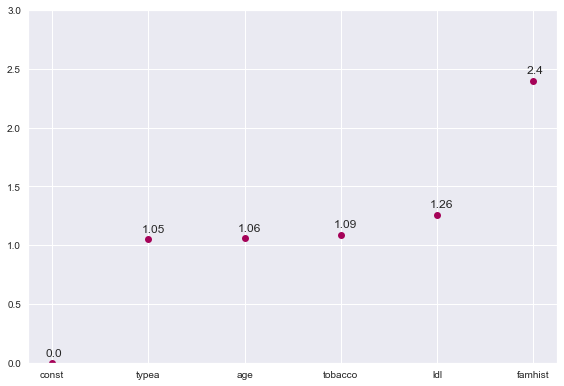

```python
fig = plt.figure()
ax = fig.add_subplot(111)
values = np.round(np.exp(result1.params).sort_values().values,2)
labels = np.exp(result1.params).sort_values().index

_ = plt.plot(range(len(labels)), values, 'mo') # Plotting data
_ = plt.xticks(range(len(labels)), labels) # Redefining x-axis labels
_ = plt.tight_layout()

for i, v in enumerate(values):
    ax.annotate(str(v), xy=(i,v), xytext=(-7,7), textcoords='offset points')
_ = plt.ylim(0,3)
```

Odd' Ratio Give a more deep insight to which variables are most significant

# iv. Obtain a confusion matrix based on the cut-off probability 0.5 and report precision.

```python
from sklearn.metrics import  classification_report,precision_score
print(classification_report(y_val,logreg.predict(X_val_rs)))
print(precision_score(y_val,logreg.predict(X_val_rs)))
```

```
              precision    recall  f1-score   support

           0       0.73      0.77      0.75        70
           1       0.52      0.46      0.49        37

    accuracy                           0.66       107
   macro avg       0.62      0.62      0.62       107
weighted avg       0.66      0.66      0.66       107

0.5151515151515151
```

# (B) Decision Tree

```python
from sklearn.tree import DecisionTreeClassifier
from sklearn.metrics import accuracy_score
dt = DecisionTreeClassifier()
dtt = DecisionTreeClassifier(max_depth=7,max_leaf_nodes=6)
dt.fit(X_trn_rs,y_trn)
```

```
DecisionTreeClassifier()
```

```python
print("ACCURACY      :",np.round(cross_validate(dtt,X_trn_rs,y_trn,cv=7)['test_score'].mean()*100,2))
print("ROC AUC SCORE :",np.round(cross_val_score(dtt, X_trn_rs, y_trn, scoring="roc_auc", cv = 7).mean()*100,2))
```

```
ACCURACY      : 65.96
ROC AUC SCORE : 66.87
```

```python
train_accuracies = []
test_accuracies = []
for depth in range(1, 7):
  clf = DecisionTreeClassifier(max_depth=depth)
  clf.fit(X_trn_rs, y_trn)
  # create training & test predictions
  train_predictions = clf.predict(X_trn_rs)
  test_predictions = clf.predict(X_val_rs)
  # calculate training & test accuracies
  train_accuracy = accuracy_score(train_predictions, y_trn)
  test_accuracy = accuracy_score(test_predictions, y_val)
  # append accuracies
  train_accuracies.append(train_accuracy)
  test_accuracies.append(test_accuracy)
```

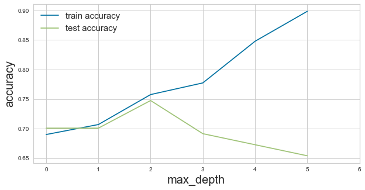

```python
plt.figure(figsize=(10, 5))
sns.set_style("whitegrid")
plt.plot(train_accuracies, label="train accuracy")
plt.plot(test_accuracies, label="test accuracy")
plt.legend(loc="upper left", prop={'size': 15})
plt.xticks(range(0, 7, 1))
plt.xlabel("max_depth", size=20)
plt.ylabel("accuracy", size=20)
plt.show()
```

# i. CART and clearly identify and report predictor which is classifying chd

```python
dt.feature_importances_
```

```
array([0.07751336, 0.12969748, 0.20483759, 0.12138589, 0.0276586 ,
       0.12958892, 0.05043917, 0.11563591, 0.14324308])
```

```python
X_trn.columns # are the predictors which are classifying the Decision Tree
```

```
Index(['sbp', 'tobacco', 'ldl', 'adiposity', 'famhist', 'typea', 'obesity',
       'alcohol', 'age'],
      dtype='object')
```

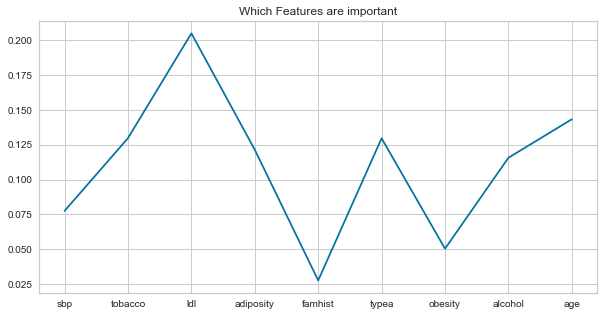

```python
_ = plt.figure(figsize = (10,5))
_ = sns.lineplot(x=X_trn.columns,y=dt.feature_importances_)
_ = plt.title('Which Features are important')
```

# Random Forests

```python
from sklearn.ensemble import RandomForestClassifier
rf = RandomForestClassifier(n_estimators=200,random_state=39)
rff = RandomForestClassifier()
rf.fit(X_trn,y_trn)
rf.score(X_val,y_val)
```

```
0.7476635514018691
```

```python
print("ACCURACY      :",np.round(cross_validate(rff,X_trn,y_trn,cv=7)['test_score'].mean()*100,2))
print("ROC AUC SCORE :",np.round(cross_val_score(rff,X_trn,y_trn, scoring="roc_auc", cv = 7).mean()*100,2))
```

```
ACCURACY      : 65.93
ROC AUC SCORE : 70.16
```

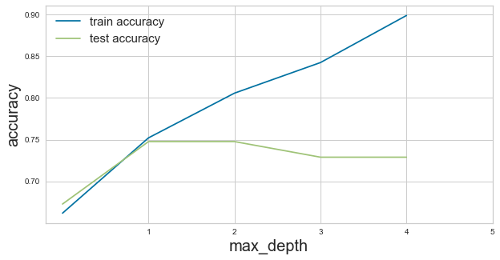

```python
train_accuracies = []
test_accuracies = []
for depth in range(1,6):
  clf = RandomForestClassifier(max_depth=depth)
  clf.fit(X_trn_rs, y_trn)
  # create training & test predictions
  train_predictions = clf.predict(X_trn_rs)
  test_predictions = clf.predict(X_val_rs)
  # calculate training & test accuracies
  train_accuracy = accuracy_score(train_predictions, y_trn)
  test_accuracy = accuracy_score(test_predictions, y_val)
  # append accuracies
  train_accuracies.append(train_accuracy)
  test_accuracies.append(test_accuracy)

plt.figure(figsize=(10, 5))
sns.set_style("whitegrid")
plt.plot(train_accuracies, label="train accuracy")
plt.plot(test_accuracies, label="test accuracy")
plt.legend(loc=0, prop={'size': 15})
plt.xticks(range(1,6))
plt.xlabel("max_depth", size=20)
plt.ylabel("accuracy", size=20)
plt.show()
```

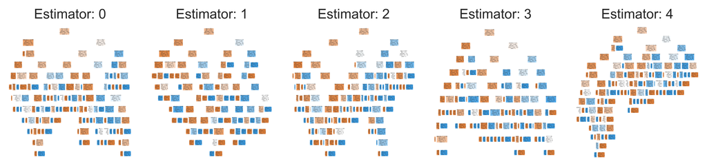

```python
fn=X_trn.columns
cn='chd'
fig, axes = plt.subplots(nrows = 1,ncols = 5,figsize = (10,2), dpi=900)
for index in range(0, 5):
    plot_tree(rf.estimators_[index],
                   feature_names = fn,
                   class_names=cn,
                   filled = True,
                   ax = axes[index]);

    axes[index].set_title('Estimator: ' + str(index), fontsize = 11)
fig.savefig('rf_5trees.png')
```

# ii. Random Forest and clearly identify and report predictor which is classifying chd

```python
rf.feature_importances_
```

```
array([0.10013249, 0.15734178, 0.15088866, 0.10690655, 0.04431813,
       0.09780292, 0.09281993, 0.07895273, 0.17083682])
```

```python
X_trn.columns # the predictors classifying
```

```
Index(['sbp', 'tobacco', 'ldl', 'adiposity', 'famhist', 'typea', 'obesity',
       'alcohol', 'age'],
      dtype='object')
```

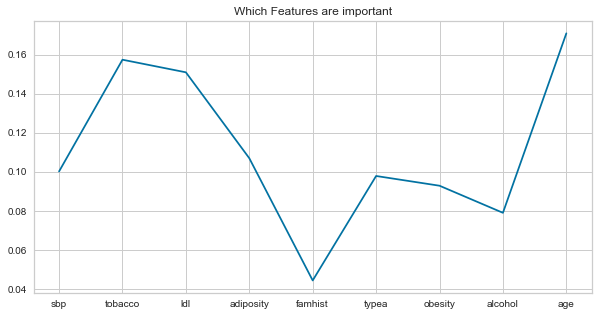

```python
_ = plt.figure(figsize = (10,5))
_ = sns.lineplot(x=X_trn.columns,y=rf.feature_importances_)
_ = plt.title('Which Features are important')
```

# iii. Choose the best classifier among (i) and (ii) of (b) by clearly stating the reason of selection. Also plot that decision tree and report the most important splitting criteria .

```python
acc_dt = np.round(cross_validate(dtt,X_trn_rs,y_trn,cv=7)['test_score'].mean()*100,2)
auc_dt = np.round(cross_val_score(dtt, X_trn_rs, y_trn, scoring="roc_auc", cv = 7).mean()*100,2)
DT = list((acc_dt,auc_dt))

acc_rf = np.round(cross_validate(rff,X_trn,y_trn,cv=7)['test_score'].mean()*100,2)
auc_rf = np.round(cross_val_score(rff,X_trn,y_trn, scoring="roc_auc", cv = 7).mean()*100,2)
RF = list((acc_rf,auc_rf))
```

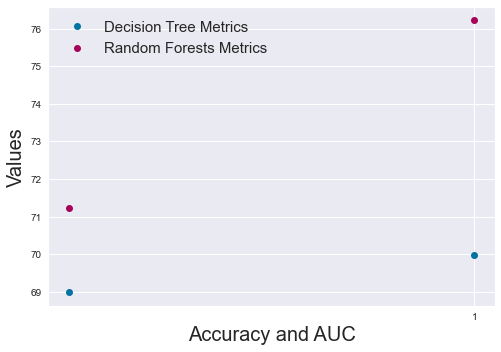

```python
sns.set_style("darkgrid")
_ = plt.plot(DT,'o',label = 'Decision Tree Metrics')
_ = plt.plot(RF,'mo',label = 'Random Forests Metrics')
_ = plt.legend(loc=0, prop={'size': 15})
_ = plt.xticks(range(1,2))
_ = plt.yticks(range(69,77))
_ = plt.xlabel("Accuracy and AUC", size=20)
_ = plt.ylabel("Values", size=20)
plt.show()
```

We can see that the ensemble method by which Random Forest was created gives us the **upper edge** be it Accuracy or AUC

The most Important Split made by the Variable is **AGE**, the reason being it is being able to bifurcate the rest of the predictors while having the least impurity

[figure not shown]

```python
print(precision_score(y_val,rf.predict(X_val)))
```

```
0.6785714285714286
```

# (c) Compare the logistic regression model and decision tree classifier performance?

```python
acc_dt = np.round(cross_validate(dtt,X_trn_rs,y_trn,cv=7)['test_score'].mean()*100,2)
auc_dt = np.round(cross_val_score(dtt, X_trn_rs, y_trn, scoring="roc_auc", cv = 7).mean()*100,2)
DT = list((acc_dt,auc_dt))

acc_lr = np.round(cross_validate(logreg,X_trn,y_trn,cv=7)['test_score'].mean()*100,2)
auc_lr = np.round(cross_val_score(logreg,X_trn,y_trn, scoring="roc_auc", cv = 7).mean()*100,2)
LR = list((acc_lr,auc_lr))
```

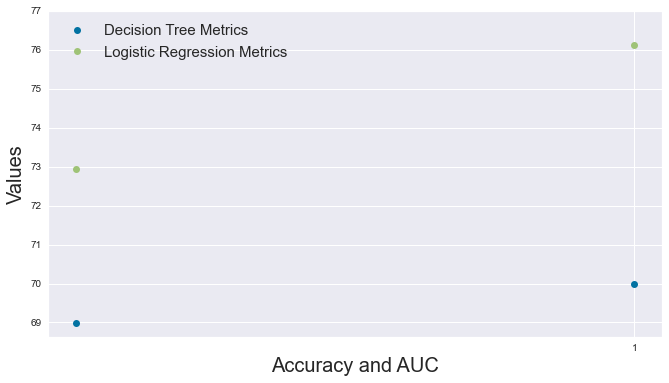

```python
sns.set_style("darkgrid")
_ = plt.figure(figsize=(11,6))
_ = plt.plot(DT,'o',label = 'Decision Tree Metrics')
_ = plt.plot(LR,'o',label = 'Logistic Regression Metrics')
_ = plt.legend(loc=0, prop={'size': 15})
_ = plt.xticks(range(1,2))
_ = plt.yticks(range(69,78))
_ = plt.xlabel("Accuracy and AUC", size=20)
_ = plt.ylabel("Values", size=20)
plt.show()
```

We can see that the Logistic Regression Classifier is a better model than the Desicion Tree Classifier as the Accuracy and the Area Under the Curve is better than that of Desicion Tree

# Question 3

```python
ipl = pd.read_excel('IPL2013.xlsx',sheet_name=0);ipl.head()
```

|  | Sl.NO. | PLAYER NAME | AGE | PLAYING ROLE | T-RUNS-S | T-WKTS | ODI-RUNS-S | ODI-SR-B | ODI-WKTS | ODI-SR-BL | ... | AVE-B | SR-B | SIXERS | RUNS-C | WKTS | AVE-BL | ECON | SR-BL | AUCTION YEAR | SOLD PRICE |
| --- | --- | --- | --- | --- | --- | --- | --- | --- | --- | --- | --- | --- | --- | --- | --- | --- | --- | --- | --- | --- | --- |
| 0 | 1 | Abdulla, YA | 2 | Allrounder | 0 | 0 | 0 | 0.00 | 0 | 0.0 | ... | 0.00 | 0.00 | 0 | 307 | 15 | 20.47 | 8.90 | 13.93 | 2009 | 50000 |
| 1 | 2 | Abdur Razzak | 2 | Bowler | 214 | 18 | 657 | 71.41 | 185 | 37.6 | ... | 0.00 | 0.00 | 0 | 29 | 0 | 0.00 | 14.50 | 0.00 | 2008 | 50000 |
| 2 | 3 | Agarkar, AB | 2 | Bowler | 571 | 58 | 1269 | 80.62 | 288 | 32.9 | ... | 18.56 | 121.01 | 5 | 1059 | 29 | 36.52 | 8.81 | 24.90 | 2008 | 350000 |
| 3 | 4 | Ashwin, R | 1 | Bowler | 284 | 31 | 241 | 84.56 | 51 | 36.8 | ... | 5.80 | 76.32 | 0 | 1125 | 49 | 22.96 | 6.23 | 22.14 | 2011 | 850000 |
| 4 | 5 | Badrinath, S | 2 | Batsman | 63 | 0 | 79 | 45.93 | 0 | 0.0 | ... | 32.93 | 120.71 | 28 | 0 | 0 | 0.00 | 0.00 | 0.00 | 2011 | 800000 |

5 rows × 23 columns

```python
X = ipl.drop(['Sl.NO.','PLAYER NAME',"SOLD PRICE"],axis = 1);X.head()
```

|  | AGE | PLAYING ROLE | T-RUNS-S | T-WKTS | ODI-RUNS-S | ODI-SR-B | ODI-WKTS | ODI-SR-BL | CAPTAINCY EXP | RUNS-S | HS | AVE-B | SR-B | SIXERS | RUNS-C | WKTS | AVE-BL | ECON | SR-BL | AUCTION YEAR |
| --- | --- | --- | --- | --- | --- | --- | --- | --- | --- | --- | --- | --- | --- | --- | --- | --- | --- | --- | --- | --- |
| 0 | 2 | Allrounder | 0 | 0 | 0 | 0.00 | 0 | 0.0 | 0 | 0 | 0 | 0.00 | 0.00 | 0 | 307 | 15 | 20.47 | 8.90 | 13.93 | 2009 |
| 1 | 2 | Bowler | 214 | 18 | 657 | 71.41 | 185 | 37.6 | 0 | 0 | 0 | 0.00 | 0.00 | 0 | 29 | 0 | 0.00 | 14.50 | 0.00 | 2008 |
| 2 | 2 | Bowler | 571 | 58 | 1269 | 80.62 | 288 | 32.9 | 0 | 167 | 39 | 18.56 | 121.01 | 5 | 1059 | 29 | 36.52 | 8.81 | 24.90 | 2008 |
| 3 | 1 | Bowler | 284 | 31 | 241 | 84.56 | 51 | 36.8 | 0 | 58 | 11 | 5.80 | 76.32 | 0 | 1125 | 49 | 22.96 | 6.23 | 22.14 | 2011 |
| 4 | 2 | Batsman | 63 | 0 | 79 | 45.93 | 0 | 0.0 | 0 | 1317 | 71 | 32.93 | 120.71 | 28 | 0 | 0 | 0.00 | 0.00 | 0.00 | 2011 |

```python
y = np.log(ipl['SOLD PRICE']/1e5)
```

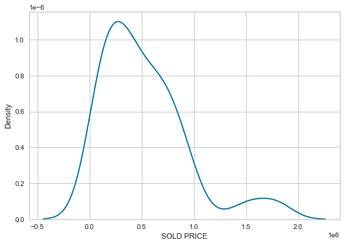

```python
_ = sns.kdeplot((np.exp(y)*1e5)) #Distn is slight Bi Modal,might Hamper Predictions
```

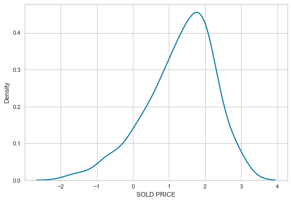

```python
_ = sns.kdeplot(y) #Applying Log Transformation we get a smooth almost normal curve which brings down the RMSE
```

```python
X_trn,X_val,y_trn,y_val = train_test_split(X,y,test_size = .2)
```

```python
le = sklearn.preprocessing.LabelEncoder()

X_trn.loc[:,'PLAYING ROLE'] = le.fit_transform(X_trn['PLAYING ROLE'])

X_val.loc[:,'PLAYING ROLE'] = le.transform(X_val['PLAYING ROLE'])
```

```python
rs = RobustScaler()

X_trn_rs = rs.fit_transform(X_trn)

X_val_rs = rs.transform(X_val)
```

```python
from sklearn.linear_model import LinearRegression
linr = LinearRegression()
```

```python
-cross_validate(linr,X_trn,y_trn,scoring='neg_mean_squared_error')['test_score'].mean()
```

```
0.7909711859483206
```